# Bayesian_hw4

192STG11

# ch4 본문 프로그램 실습 코드

## 4.1.1 선형회귀모형 분석

```r
rmvnorm <- function(n, mu, Sig){
  p = length(mu)
  R = chol(Sig) # R%*%t(R) = Sigma 만족하는 unique upper triangle 찾아줌
  z = matrix(rnorm(n*p), n, p)
  tt = z%*%R + matrix(mu, n, p, byrow = T)
}

dat = read.csv('../immigrants.csv')
y = dat$wage
n = length(y)
X = cbind(rep(1, n), dat$sp, dat$lit)
p = ncol(X)

# sigma^2의 사전모수
a = 1
b = 1
XtX = t(X) %*% X
XtX.inv = solve(XtX)
Xty = t(X)%*%y
beta.hat = beta_lse = as.vector(XtX%*%Xty)
sigsq.hat = sum((y-X%*%beta_lse)^2)/(n-p)
beta0 = beta_lse
Sig0 = diag(diag(XtX.inv))*sigsq.hat*100
Sig0.inv = solve(Sig0)

N = 10000; nburn = 1000
sigsq.samples = rep(0, N)
beta.samples = matrix(0, N, p)

beta.init = beta_lse
sigsq.init = sigsq.hat
beta = beta.init; sigsq = sigsq.hat

# start Gibbs Sampling
for(iter in 1:(N + nburn)){
  Sig.beta = solve(Sig0.inv + XtX/sigsq)
  mu.beta = Sig.beta %*% (Sig0.inv %*% beta0 + 1/sigsq*Xty)
  beta = as.vector(rmvnorm(1, mu.beta, Sig.beta))

  SSR = sum((y - X%*%beta)^2)
  sigsq = 1/rgamma(1, n/2 + a, 1/2*SSR + b)

  if(iter > nburn){
    beta.samples[iter-nburn, ] = beta
    sigsq.samples[iter-nburn] = sigsq
  }

}

#### 95% HPD interval ####
(ci_beta = round(apply(beta.samples, 2, quantile, probs = c(0.025, 0.975)), 4))
```

```
##          [,1]   [,2]   [,3]
## 2.5%  -0.0898 0.0170 0.0397
## 97.5%  5.1775 0.0595 0.1194
```

```r
(ci_sigsq = round(quantile(sigsq.samples, c(0.025, 0.975)), 4))
```

```
##   2.5%  97.5%
## 0.7041 1.8443
```

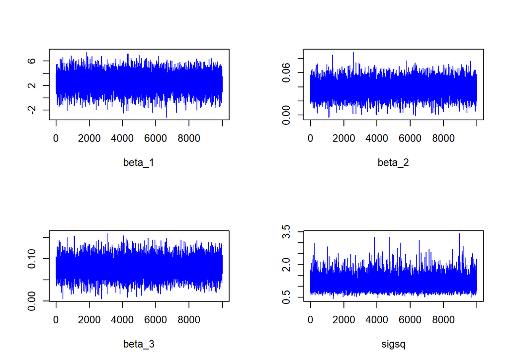

```r
#### Figure 4.1 예 4.1 모수에 대한 경로그림 및 자기상관 ####
par(mfrow = c(2,2))
for(i in 1:3) plot(beta.samples[,i], type = "l", xlab = paste0("beta_", i), ylab = "", col = "blue")
plot(sigsq.samples, xlab = "sigsq", ylab = "", type = 'l', col= 'blue')
```

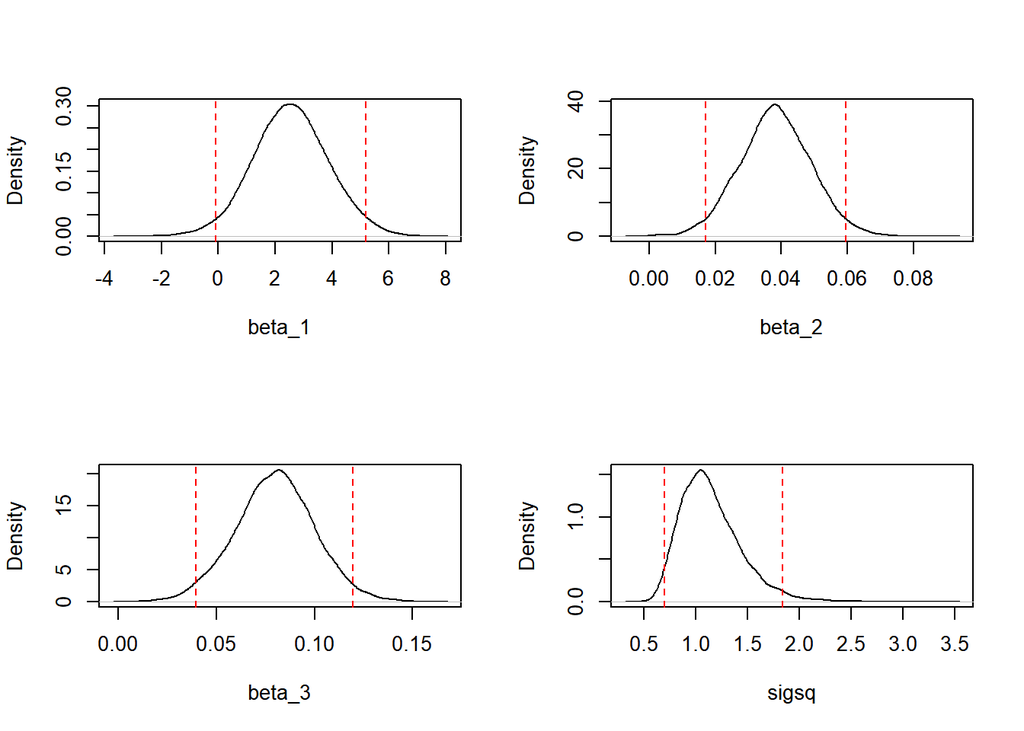

```r
#### Figure 4.2 예 4.1 사후밀도함수와 95% HPD 구간 ####
par(mfrow = c(2, 2))
for(i in 1:3){
  plot(density(beta.samples[,i]), type = 'l', main = "", xlab = paste0("beta_", i))
  abline(v = ci_beta[,i], col = 2, lty = 2)
}

plot(density(sigsq.samples), main = "", xlab = "sigsq", type = "l")
abline(v = ci_sigsq, col = 2, lty = 2)
```

## 4.1.2 제한된 다변량 정규분포로부터의 표본추출

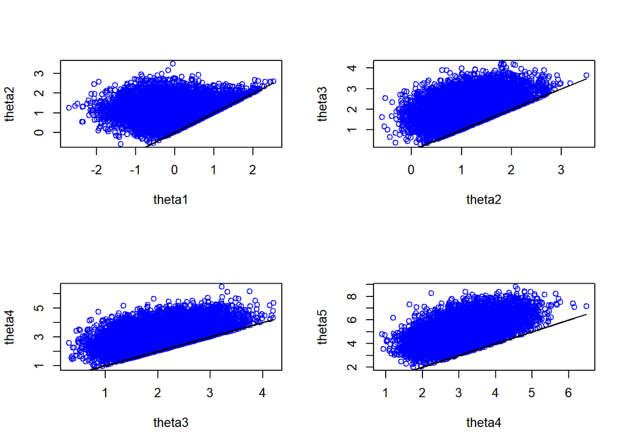

```r
library(truncnorm)

k = 5
mu = c(0, 1, 2, 3, 5)
Sig = matrix(0.7, k, k) + diag(k)*0.3
A = solve(Sig)

m = 1000
N = 10000
theta.init = c(0, 1, 2, 3, 4) ## 제한 조건을 만족하는 초기치 선택
theta.samples = matrix(0, N, k)
theta = theta.init
for(iter in 1:(m+N)){
  for(i in 1:k){
    vec.Ai = A[, -i]
    vec.mi = (theta-mu)[-i]
    cond.mean = mu[i] - 1/A[i,i] * vec.Ai %*% vec.mi
    cond.sd = 1/sqrt(A[i,i])
    a = ifelse(i == 1, -Inf, theta[i-1])
    b = ifelse(i == k, Inf, theta[i+1])
    theta[i] = rtruncnorm(1, as.double(a), as.double(b), cond.mean, cond.sd)

  }
  if(iter>m) theta.samples[iter-m, ] = theta
}


#### Figure 4.3 예 4.2 모수산점도 ####
par(mfrow = c(2,2))
plot(theta.samples[, c(1,2)], xlab = "theta1", ylab = "theta2", col = "blue")
lines(theta.samples[,1], theta.samples[,1], type = 'l')
plot(theta.samples[, c(2, 3)], xlab = "theta2", ylab = "theta3", col = "blue")
lines(theta.samples[,2], theta.samples[,2], type = 'l')
plot(theta.samples[, c(3, 4)], xlab = "theta3", ylab = "theta4", col = "blue")
lines(theta.samples[,3], theta.samples[,3], type = 'l')
plot(theta.samples[, c(4, 5)], xlab = "theta4", ylab = "theta5", col = "blue")
lines(theta.samples[,4], theta.samples[,4], type = 'l')
```

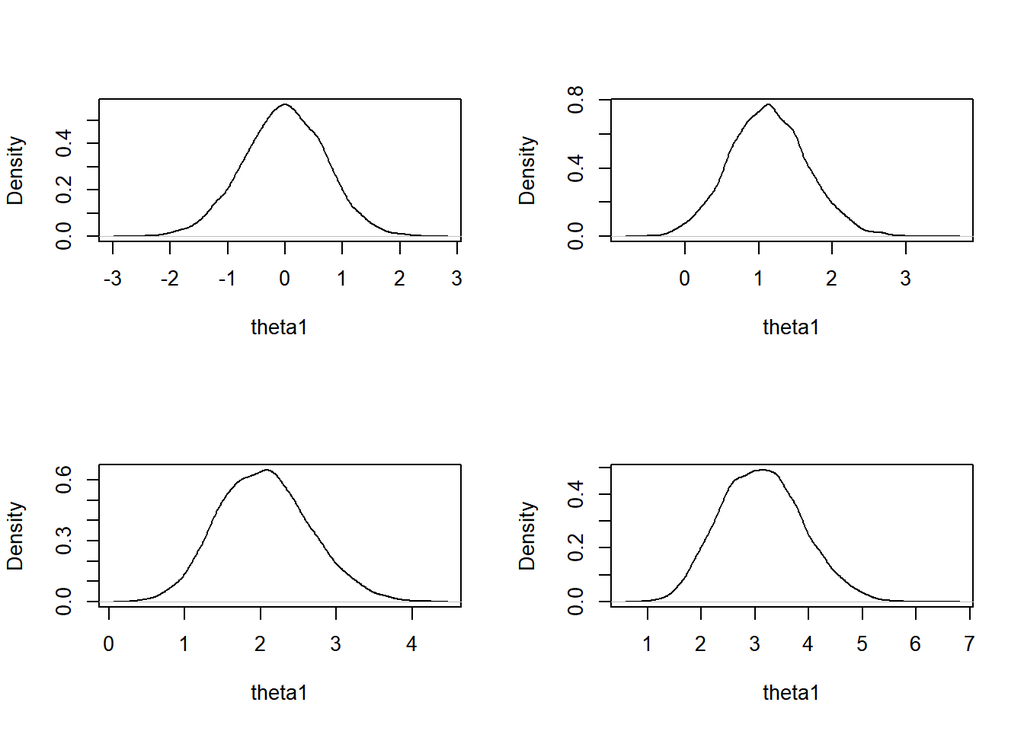

```r
#### Figure 4.4 예 4.2 모수의 사후밀도 ####
plot(density(theta.samples[,1]), xlab = "theta1", main = "")
plot(density(theta.samples[,2]), xlab = "theta1", main = "")
plot(density(theta.samples[,3]), xlab = "theta1", main = "")
plot(density(theta.samples[,4]), xlab = "theta1", main = "")
```

## 4.2 매트로폴리스-해스팅스

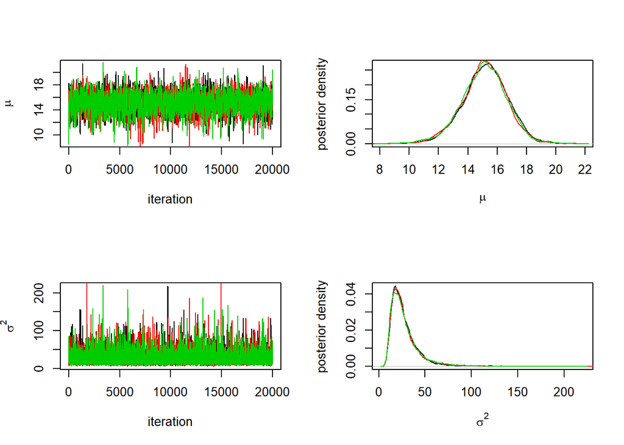

```r
#1)입력 및 준비단계 a) 데이터와 사전모수 입력
mu0=10 ; sigsq0=25 ; a=0.5 ; b=1
x<-c(10,13,15,11,9,18,20,17,23,21)
dataList=list(x=x,mu0=mu0,sigsq0=sigsq0,a=a,b=b)

#사후밀도함수의 커널을 계산. 메트로폴리스해스팅스에서 상수항은 약분되기 때문에 함수부분만 계산해도 됨

#1)입력 및 준비단계 b) 사후밀도함수의 커널을 계산하는 함수 작성
###compute posterior kernel for Metropolis
post.normal_mu_sigsq=function(theta,dataList){
  # retrieve data from dataList
  x=dataList$x
  mu=dataList$mu0
  sigsq0=dataList$sigsq0
  a=dataList$a
  b=dataList$b

  mu=theta[1] ; sigsq=theta[2]
  f=exp(-0.5*length(x)*log(sigsq)-0.5*sum((x-mu)^2)/sigsq-0.5*(mu-mu0)^2/sigsq0-(a+1)*log(sigsq)-b/sigsq)
  return(f)
}

#2) MCMC 표본추출함수 작성
###random walk metropolis algorithm
Metropolis_normal_mu_sigsq=function(nsim,nburn,delta,dataList,initsList){
  #initial values of mu and log.sigsq
  mu=initsList$mu
  log.sigsq=log(initsList$sigsq)
  theta.curr=c(mu,log.sigsq)
  p=length(theta.curr)

  #Start iterations
  para.samples=matrix(0,nsim,p)
  for (iter in 1:(nsim+nburn)){
    z=rnorm(p,0,1)
    theta.prop=z*delta+theta.curr
    mu.curr=theta.curr[1]
    sigsq.curr=exp(theta.curr[2])
    mu.prop=theta.prop[1]
    sigsq.prop=exp(theta.prop[2])
    alpha=post.normal_mu_sigsq(c(mu.prop,sigsq.prop),dataList)/post.normal_mu_sigsq(c(mu.curr,sigsq.curr),dataList)*sigsq.prop/sigsq.curr
    if(runif(1)<alpha) {theta.next<-theta.prop} else theta.next<-theta.curr

    theta.curr=theta.next
    if(iter>nburn) para.samples[iter-nburn,]=c(theta.next[1],exp(theta.next[2]))

  }
  #end iterations
  return(para.samples)
}

#3)다중체인 mcmc a)MCMC 준비단계 이후의 반복수, 다중체인의 수 선택
nChains=3
nsim=20000 ; nburn=5000
p=2 # num of para
mcmc.samples=array(0,dim=c(nsim,p,nChains)) # array to save samples

#3)다중체인 mcmc b) 랜덤워크의 표준편차 delta 선택
#delta는 여러 가지 값 가능
delta=1

#3)다중체인 mcmc c) 초기치 선택
##Generate random initial values
inits.random=function(x){
  resampledX=sample(x,replace=T)
  muInit=mean(resampledX)
  sigsqInit=var(resampledX)
  return(list(mu=muInit,sigsq=sigsqInit))
}

##start iteration
for (ich in 1:nChains){
  initsList=inits.random(x)
  mcmc.samples[,,ich]=Metropolis_normal_mu_sigsq(nsim,nburn,delta,dataList,initsList)
}

#4)수렴진단
###Figure 4.5 ; mu와 sigma의 경로그림과 사후밀도함수
mu.samples=mcmc.samples[,1,]
sigsq.samples=mcmc.samples[,2,]

par(mfrow = c(2,2))
plot(mu.samples[,1],type="l",xlab="iteration",ylab=quote(mu))
lines(mu.samples[,2],col=2)
lines(mu.samples[,3],col=3)

plot(density(mu.samples[,1]),xlab=quote(mu),ylab="posterior density",main="")
lines(density(mu.samples[,2]),col=2)
lines(density(mu.samples[,3]),col=3)

plot(sigsq.samples[,1],type="l",xlab="iteration",ylab=quote(sigma^2))
lines(sigsq.samples[,2],col=2)
lines(sigsq.samples[,3],col=3)

plot(density(sigsq.samples[,1]),xlab=quote(sigma^2),ylab="posterior density",main="")
lines(density(sigsq.samples[,2]),col=2)
lines(density(sigsq.samples[,3]),col=3)
```

```r
# Gelman 상수
library(coda)

samples.1 = mcmc(mcmc.samples[,,1])
samples.2 = mcmc(mcmc.samples[,,2])
samples.3 = mcmc(mcmc.samples[,,3])

codaSamples = mcmc.list(list(samples.1, samples.2, samples.3))
gelman = gelman.diag(codaSamples)
gelman
```

```
## Potential scale reduction factors:
##
##      Point est. Upper C.I.
## [1,]          1          1
## [2,]          1          1
##
## Multivariate psrf
##
## 1
```

```r
Metro.draws = mcmc(mcmc.samples[,,1])
accept.rate = 1 - rejectionRate(Metro.draws)
accept.rate
```

```
##      var1      var2
## 0.4087204 0.4087204
```

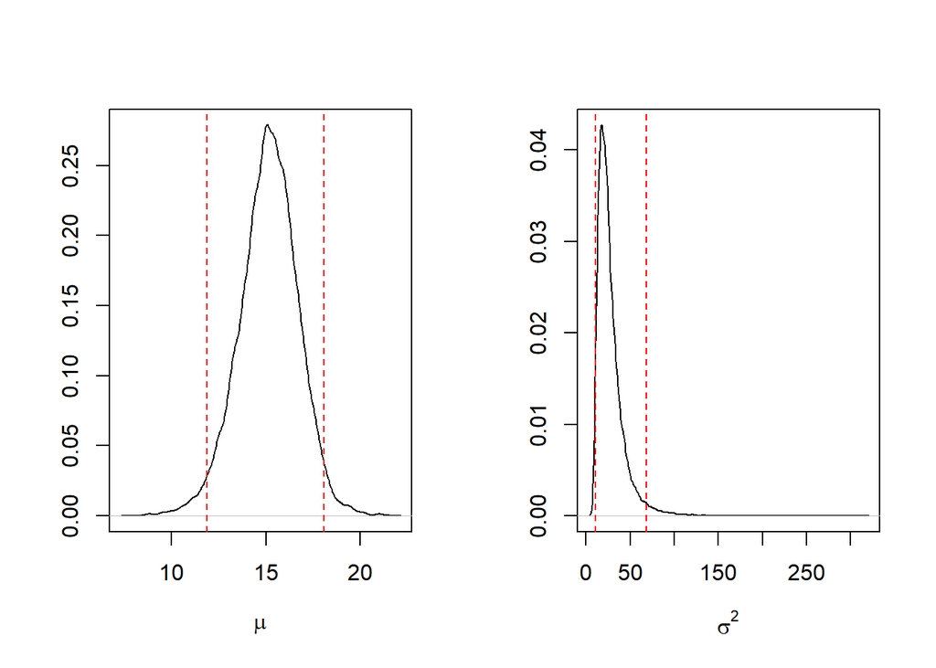

```r
# 5) 베이지안 사후추론
#### Posterior inference ####
mcmc.samples.combined = rbind(mcmc.samples[,,1], mcmc.samples[,,2], mcmc.samples[,,3])
para.hat = apply(mcmc.samples.combined, 2, mean)
HPD = apply(mcmc.samples.combined, 2, function(x) quantile(x, c(0.025, 0.975)))

#### Figure 4.6 예 4.3에서 mu와 sigma의 주변 사후밀도함수와 95% HPD 구간 ####
par(mfrow = c(1,2))
plot(density(mcmc.samples.combined[,1]), xlab = quote(mu), ylab = "", main = "")
abline(v = HPD[,1], lty = 2, col = 2)
plot(density(mcmc.samples.combined[,2]), xlab = quote(sigma^2), ylab = "", main = "")
abline(v = HPD[,2], lty = 2, col = 2)
```

```r
# 1. delta = 0.3
#### MCMC Simulation ####
nChains = 3
nsim <- 2000; nburn <- 0; delta <- 0.3
p = 2
mcmc.samples = array(0, dim=c(nsim, p, nChains))
for(ich in 1:nChains){
  initsList = inits.random(x)
  mcmc.samples[,,ich] = Metropolis_normal_mu_sigsq(nsim, nburn, delta, dataList, initsList)
}
Metro.draws = mcmc(mcmc.samples[,,1])
accept.rate = 1 - rejectionRate(Metro.draws); accept.rate
```

```
##      var1      var2
## 0.7593797 0.7593797
```

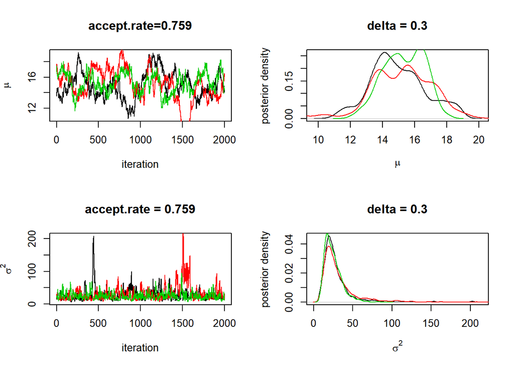

```r
mu.samples = mcmc.samples[,1,]
sigsq.samples = mcmc.samples[,2,]

#### Figure 4.7 예 4.3에서 경로그림과 사후밀도함수 ####
par(mfrow = c(2,2))
plot(mu.samples[,1], type = 'l', xlab = "iteration", ylab = quote(mu), main = paste0("accept.rate=", round(accept.rate[1],3)))
lines(mu.samples[,2], col = 2)
lines(mu.samples[,3], col = 3)

plot(density(mu.samples[,1]), type = 'l', xlab = quote(mu), ylab = "posterior density", main = paste0("delta = ", round(delta, 2)))
lines(density(mu.samples[,2]), col = 2)
lines(density(mu.samples[,3]), col = 3)

plot(sigsq.samples[,1], type = 'l', xlab = "iteration", ylab = quote(sigma^2), main = paste0("accept.rate = ", round(accept.rate[1], 3)))
lines(sigsq.samples[,2], col = 2)
lines(sigsq.samples[,3], col = 3)

plot(density(sigsq.samples[,1]), type = 'l', xlab = quote(sigma^2), ylab = "posterior density",
     main = paste0("delta = ", round(delta, 2)))
lines(density(sigsq.samples[,2]), col = 2)
lines(density(sigsq.samples[,3]), col = 3)
```

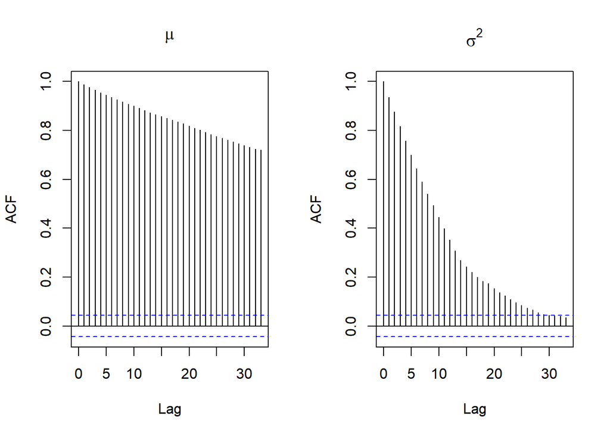

```r
#### Figure 4.8 예 4.2에서 자기상관 ####
par(mfrow=c(1,2))
acf(mu.samples[,1], main = quote(mu))
acf(sigsq.samples[,1], main = quote(sigma^2))
```

```r
# 2. delta = 1.5
nChains = 3
nsim <- 20000; nburn <- 5000; delta <- 1.5
p = 2
mcmc.samples = array(0, dim=c(nsim, p, nChains))
for(ich in 1:nChains){
  initsList = inits.random(x)
  mcmc.samples[,,ich] = Metropolis_normal_mu_sigsq(nsim, nburn, delta, dataList, initsList)
}
Metro.draws = mcmc(mcmc.samples[,,1])
accept.rate = 1 - rejectionRate(Metro.draws); accept.rate
```

```
##      var1      var2
## 0.2692635 0.2692635
```

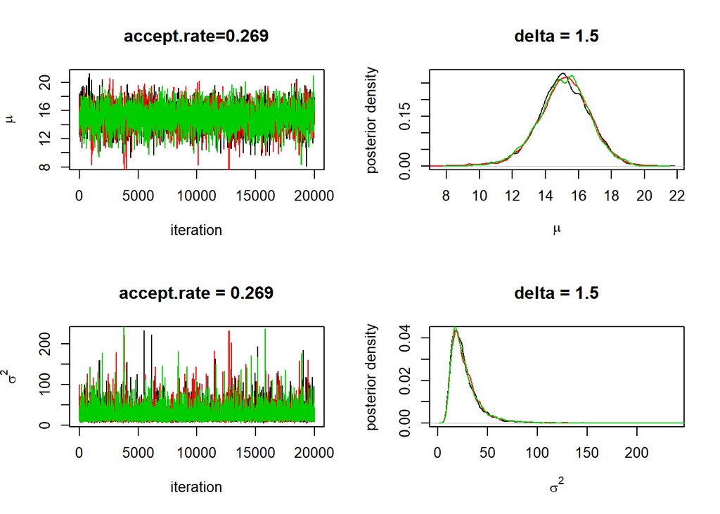

```r
mu.samples = mcmc.samples[,1,]
sigsq.samples = mcmc.samples[,2,]

#### Figure 4.7 예 4.3에서 경로그림과 사후밀도함수 ####
par(mfrow = c(2,2))
plot(mu.samples[,1], type = 'l', xlab = "iteration", ylab = quote(mu), main = paste0("accept.rate=", round(accept.rate[1],3)))
lines(mu.samples[,2], col = 2)
lines(mu.samples[,3], col = 3)

plot(density(mu.samples[,1]), type = 'l', xlab = quote(mu), ylab = "posterior density", main = paste0("delta = ", round(delta, 2)))
lines(density(mu.samples[,2]), col = 2)
lines(density(mu.samples[,3]), col = 3)

plot(sigsq.samples[,1], type = 'l', xlab = "iteration", ylab = quote(sigma^2), main = paste0("accept.rate = ", round(accept.rate[1], 3)))
lines(sigsq.samples[,2], col = 2)
lines(sigsq.samples[,3], col = 3)

plot(density(sigsq.samples[,1]), type = 'l', xlab = quote(sigma^2), ylab = "posterior density",
     main = paste0("delta = ", round(delta, 2)))
lines(density(sigsq.samples[,2]), col = 2)
lines(density(sigsq.samples[,3]), col = 3)
```

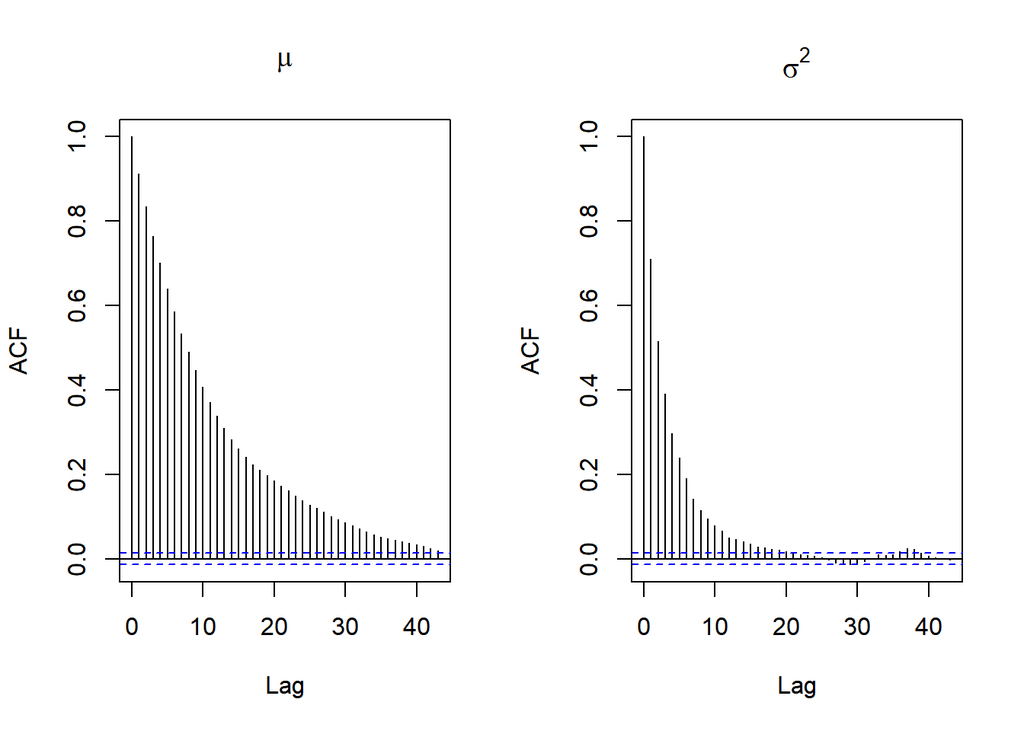

```r
#### Figure 4.8 예 4.2에서 자기상관 ####
par(mfrow=c(1,2))
acf(mu.samples[,1], main = quote(mu))
acf(sigsq.samples[,1], main = quote(sigma^2))
```

# delta = 1.5 Thinning 후

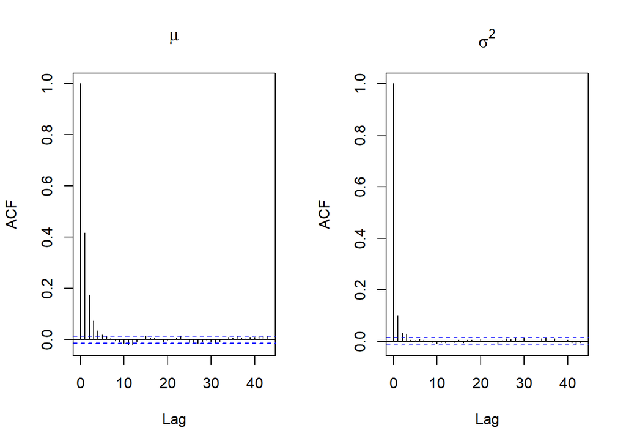

```r
###표본 추출 함수 thinning 추가
Metropolis_normal_mu_sigsq=function(nsim,nburn,nthin, delta,dataList,initsList){
  #initial values of mu and log.sigsq
  mu=initsList$mu
  log.sigsq=log(initsList$sigsq)
  theta.curr=c(mu,log.sigsq)
  p=length(theta.curr)

  #Start iterations
  para.samples=matrix(0,nsim,p)
  for (iter in 1:(nthin * nsim+nburn)){
    z=rnorm(p,0,1)
    theta.prop=z*delta+theta.curr
    mu.curr=theta.curr[1]
    sigsq.curr=exp(theta.curr[2])
    mu.prop=theta.prop[1]
    sigsq.prop=exp(theta.prop[2])
    alpha=post.normal_mu_sigsq(c(mu.prop,sigsq.prop),dataList)/post.normal_mu_sigsq(c(mu.curr,sigsq.curr),dataList)*sigsq.prop/sigsq.curr
    if(runif(1)<alpha) {theta.next<-theta.prop} else theta.next<-theta.curr

    theta.curr=theta.next
    if(iter>nburn) {
    if(iter %% nthin==0) {para.samples[(iter-nburn)/nthin,]=c(theta.next[1],exp(theta.next[2]))}
    }
  }
  #end iterations
  return(para.samples)
}

nChains = 3
nsim <- 20000; nburn <- 5000; delta <- 1.5; nthin <- 10
p = 2
mcmc.samples = array(0, dim=c(nsim, p, nChains))
for(ich in 1:nChains){
  initsList = inits.random(x)
  mcmc.samples[,,ich] = Metropolis_normal_mu_sigsq(nsim, nburn, nthin,  delta, dataList, initsList)
}

mu.samples = mcmc.samples[,1,]
sigsq.samples = mcmc.samples[,2,]


#### Figure 4.13 delta=1.5일때 nthin = 10에서 자기상관 ####
par(mfrow=c(1,2))
acf(mu.samples[,1], main = quote(mu))
acf(sigsq.samples[,1], main = quote(sigma^2))
```

# Ch4 연습문제

## 1) 4.2절의 알고리즘을 짧게 실행하여 theta의 대략적인 추정치와 분산을 추정

```r
#1)입력 및 준비단계 a) 데이터와 사전모수 입력
mu0=10 ; sigsq0=25 ; a=0.5 ; b=1
x<-c(10,13,15,11,9,18,20,17,23,21)
dataList=list(x=x,mu0=mu0,sigsq0=sigsq0,a=a,b=b)

#사후밀도함수의 커널을 계산. 메트로폴리스해스팅스에서 상수항은 약분되기 때문에 함수부분만 계산해도 됨

#1)입력 및 준비단계 b) 사후밀도함수의 커널을 계산하는 함수 작성
###compute posterior kernel for Metropolis
post.normal_mu_sigsq=function(theta,dataList){
  # retrieve data from dataList
  x=dataList$x
  mu=dataList$mu0
  sigsq0=dataList$sigsq0
  a=dataList$a
  b=dataList$b

  mu=theta[1] ; sigsq=theta[2]
  f=exp(-0.5*length(x)*log(sigsq)-0.5*sum((x-mu)^2)/sigsq-0.5*(mu-mu0)^2/sigsq0-(a+1)*log(sigsq)-b/sigsq)
  return(f)
}

#2) MCMC 표본추출함수 작성
###random walk metropolis algorithm
Metropolis_normal_mu_sigsq=function(nsim,nburn,delta,dataList,initsList){
  #initial values of mu and log.sigsq
  mu=initsList$mu
  log.sigsq=log(initsList$sigsq)
  theta.curr=c(mu,log.sigsq)
  p=length(theta.curr)

  #Start iterations
  para.samples=matrix(0,nsim,p)
  for (iter in 1:(nsim+nburn)){
    z=rnorm(p,0,1)
    theta.prop=z*delta+theta.curr
    mu.curr=theta.curr[1]
    sigsq.curr=exp(theta.curr[2])
    mu.prop=theta.prop[1]
    sigsq.prop=exp(theta.prop[2])
    alpha=post.normal_mu_sigsq(c(mu.prop,sigsq.prop),dataList)/post.normal_mu_sigsq(c(mu.curr,sigsq.curr),dataList)*sigsq.prop/sigsq.curr
    if(runif(1)<alpha) {theta.next<-theta.prop} else {theta.next<-theta.curr}

    theta.curr=theta.next
    if(iter>nburn) para.samples[iter-nburn,]=c(theta.next[1],theta.next[2])

  }
  #end iterations
  return(para.samples)
}

#3)다중체인 mcmc a)MCMC 준비단계 이후의 반복수, 다중체인의 수 선택
nChains=3
nsim=2000 ; nburn=0
p=2 # num of para
mcmc.samples=array(0,dim=c(nsim,p,nChains)) # array to save samples

#3)다중체인 mcmc b) 랜덤워크의 표준편차 delta 선택
#delta는 여러 가지 값 가능
delta=1

#3)다중체인 mcmc c) 초기치 선택
##Generate random initial values
inits.random=function(x){
  resampledX=sample(x,replace=T)
  muInit=mean(resampledX)
  sigsqInit=var(resampledX)
  return(list(mu=muInit,sigsq=sigsqInit))
}

##start iteration
for (ich in 1:nChains){
  initsList=inits.random(x)
  mcmc.samples[,,ich]=Metropolis_normal_mu_sigsq(nsim,nburn,delta,dataList,initsList)
}


#### Posterior inference ####
mcmc.samples.combined = rbind(mcmc.samples[,,1], mcmc.samples[,,2], mcmc.samples[,,3])
para.hat = apply(mcmc.samples.combined, 2, mean)
para.var = apply(mcmc.samples.combined, 2, var)

tb <- data.frame(para.hat = para.hat, para.var = para.var)
rownames(tb) <- c("mu", "log(sigma^2)")
print(tb)
```

```
##               para.hat  para.var
## mu           15.071279 2.2095754
## log(sigma^2)  3.173114 0.2033313
```

## 2) 추정된 분산에 2.4를 곱하여 랜덤워크의 분산 값으로 정한다.

```r
delta = para.var * 2.4
```

## 3) 4.2절의 알고리즘을 변형하여 위에서 구한 분산으로 후보표본을 추출하는 랜덤워크 메트로폴리스 알고리즘을 코딩한다.

```r
#### 보폭 theta의 원소마다 다른  random walk metropolis algorithm ####
Metropolis_normal_mu_sigsq_adj=function(nsim,nburn,delta,dataList,initsList){
  #initial values of mu and log.sigsq
  mu=initsList$mu
  log.sigsq=log(initsList$sigsq)
  theta.curr=c(mu,log.sigsq)
  p=length(theta.curr)

  #Start iterations
  para.samples = matrix(0,nsim,p)
  theta.prop = theta.curr * 0
  for (iter in 1:(nsim+nburn)){
    z=rnorm(p,0,1)
    theta.prop[1]=z[1]*delta[1]+theta.curr[1]
    theta.prop[2]=z[2]*delta[2]+theta.curr[2]

    mu.curr=theta.curr[1]
    sigsq.curr=exp(theta.curr[2])

    mu.prop=theta.prop[1]
    sigsq.prop=exp(theta.prop[2])

    alpha=post.normal_mu_sigsq(c(mu.prop,sigsq.prop),dataList)/post.normal_mu_sigsq(c(mu.curr,sigsq.curr),dataList)*sigsq.prop/sigsq.curr
    if(runif(1)<alpha) {theta.next<-theta.prop} else {theta.next<-theta.curr}

    theta.curr=theta.next
    if(iter>nburn) para.samples[iter-nburn,]=c(theta.next[1],exp(theta.next[2]))

  }
  #end iterations
  return(para.samples)
}
```

## 4) 랜덤워크 매트로폴리스를 짧게 수행한 후 경로그림과 후보표본의 채택확률을 계산하여 본다.

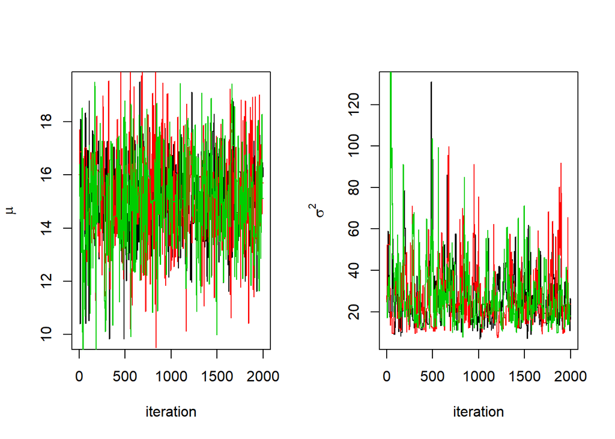

```r
nChains=3
nsim=2000 ; nburn=0; p=2
mcmc.samples=array(0,dim=c(nsim,p,nChains))
delta= para.var * 2.4

##start iteration
for (ich in 1:nChains){
  initsList=inits.random(x)
  mcmc.samples[,,ich]=Metropolis_normal_mu_sigsq_adj(nsim,nburn,delta,dataList,initsList)
}

mu.samples=mcmc.samples[,1,]
sigsq.samples=mcmc.samples[,2,]

# 경로그림
par(mfrow = c(1,2))
plot(mu.samples[,1],type="l",xlab="iteration",ylab=quote(mu))
lines(mu.samples[,2],col=2)
lines(mu.samples[,3],col=3)

plot(sigsq.samples[,1],type="l",xlab="iteration",ylab=quote(sigma^2))
lines(sigsq.samples[,2],col=2)
lines(sigsq.samples[,3],col=3)
```

```r
# 채택확률
# Chain1
Metro.draws = mcmc(mcmc.samples[,,1])
accept.rate = 1 - rejectionRate(Metro.draws)
accept.rate
```

```
##      var1      var2
## 0.2241121 0.2241121
```

```r
# Chain2
Metro.draws = mcmc(mcmc.samples[,,2])
accept.rate = 1 - rejectionRate(Metro.draws)
accept.rate
```

```
##      var1      var2
## 0.2666333 0.2666333
```

```r
# Chain3
Metro.draws = mcmc(mcmc.samples[,,3])
accept.rate = 1 - rejectionRate(Metro.draws)
accept.rate
```

```
##      var1      var2
## 0.2746373 0.2746373
```

## 5) 채택확률이 대략 24%가 되도록 분산을 조정한다.

```r
nChains=3
nsim=2000 ; nburn=0; p=2
mcmc.samples=array(0,dim=c(nsim,p,nChains))
delta= para.var * 2.4 + 0.025

##start iteration
for (ich in 1:nChains){
  initsList=inits.random(x)
  mcmc.samples[,,ich]=Metropolis_normal_mu_sigsq_adj(nsim,nburn,delta,dataList,initsList)
}

mu.samples=mcmc.samples[,1,]
sigsq.samples=mcmc.samples[,2,]

# 채택확률
# Chain1
Metro.draws = mcmc(mcmc.samples[,,1])
accept.rate = 1 - rejectionRate(Metro.draws)
accept.rate
```

```
##      var1      var2
## 0.2726363 0.2726363
```

```r
# Chain2
Metro.draws = mcmc(mcmc.samples[,,2])
accept.rate = 1 - rejectionRate(Metro.draws)
accept.rate
```

```
##      var1      var2
## 0.2561281 0.2561281
```

```r
# Chain3
Metro.draws = mcmc(mcmc.samples[,,3])
accept.rate = 1 - rejectionRate(Metro.draws)
accept.rate
```

```
##      var1      var2
## 0.2426213 0.2426213
```

```r
delta_final <- delta
```

## 6) 최종 선택된 분산을 사용하여 매트로폴리스를 충분히 길게 수행한 후 수렴속도, 효율, 사후추론 결과를 4.2절의 공통 분산을 사용하였을 경우와 비교하라.

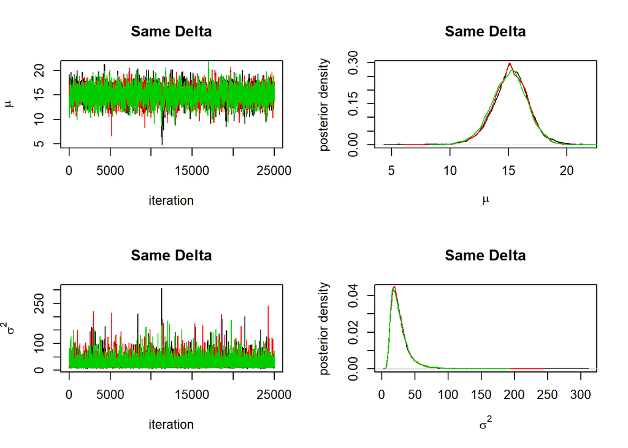

```r
# 1) 공통분산
nChains=3
nsim=25000 ; nburn=0
p=2
mcmc.samples=array(0,dim=c(nsim,p,nChains)) # array to save samples

delta=1 ## 공통분산 사용


##start iteration
for (ich in 1:nChains){
  initsList=inits.random(x)
  mcmc.samples[,,ich]=Metropolis_normal_mu_sigsq(nsim,nburn,delta,dataList,initsList)
}

mu.samples=mcmc.samples[,1,]
sigsq.samples=mcmc.samples[,2,]

par(mfrow = c(2,2))
plot(mu.samples[,1],type="l",xlab="iteration",ylab=quote(mu), main = "Same Delta")
lines(mu.samples[,2],col=2)
lines(mu.samples[,3],col=3)

plot(density(mu.samples[,1]),xlab=quote(mu),ylab="posterior density",main="Same Delta")
lines(density(mu.samples[,2]),col=2)
lines(density(mu.samples[,3]),col=3)

plot(sigsq.samples[,1],type="l",xlab="iteration",ylab=quote(sigma^2), main = "Same Delta")
lines(sigsq.samples[,2],col=2)
lines(sigsq.samples[,3],col=3)

plot(density(sigsq.samples[,1]),xlab=quote(sigma^2),ylab="posterior density",main="Same Delta")
lines(density(sigsq.samples[,2]),col=2)
lines(density(sigsq.samples[,3]),col=3)
```

```r
#### Posterior inference ####
mcmc.samples.combined = rbind(mcmc.samples[,,1], mcmc.samples[,,2], mcmc.samples[,,3])
para.hat = apply(mcmc.samples.combined, 2, mean)
HPD = apply(mcmc.samples.combined, 2, function(x) quantile(x, c(0.025, 0.975)))
HPD
```

```
##           [,1]     [,2]
## 2.5%  11.88215 10.58644
## 97.5% 18.08243 65.54940
```

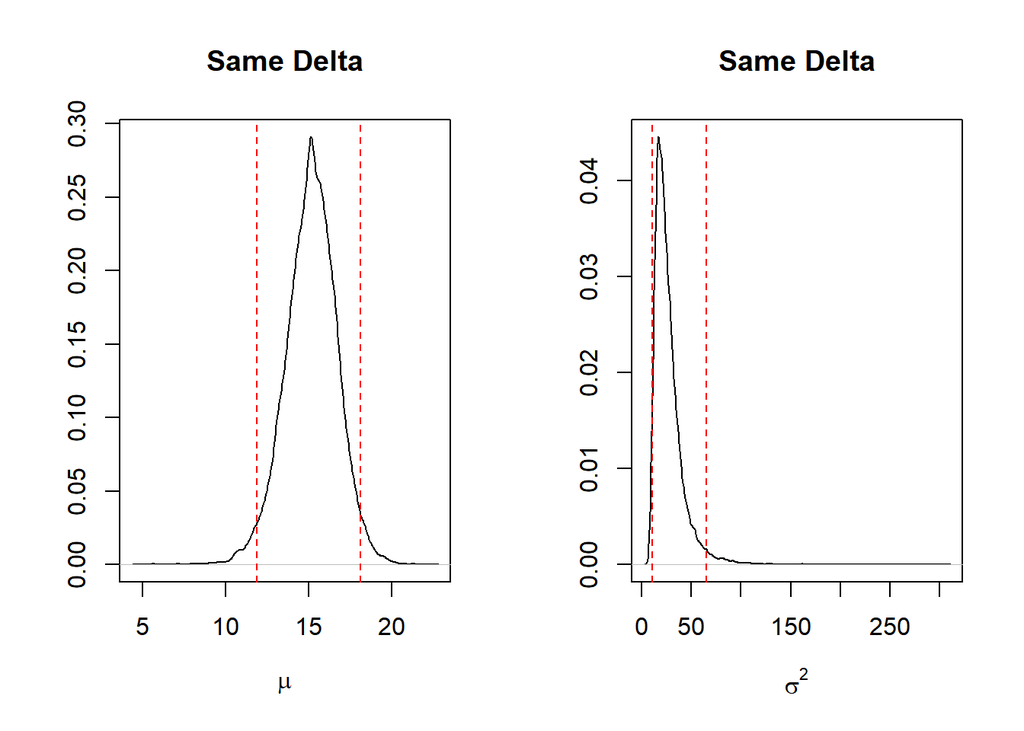

```r
#### mu와 sigma의 주변 사후밀도함수와 95% HPD 구간 ####
par(mfrow = c(1,2))
plot(density(mcmc.samples.combined[,1]), xlab = quote(mu), ylab = "", main = "Same Delta")
abline(v = HPD[,1], lty = 2, col = 2)
plot(density(mcmc.samples.combined[,2]), xlab = quote(sigma^2), ylab = "", main = "Same Delta")
abline(v = HPD[,2], lty = 2, col = 2)
```

```r
Metro.draws = mcmc(mcmc.samples[,,1])
accept.rate = 1 - rejectionRate(Metro.draws)
accept.rate
```

```
##      var1      var2
## 0.4030561 0.4030561
```

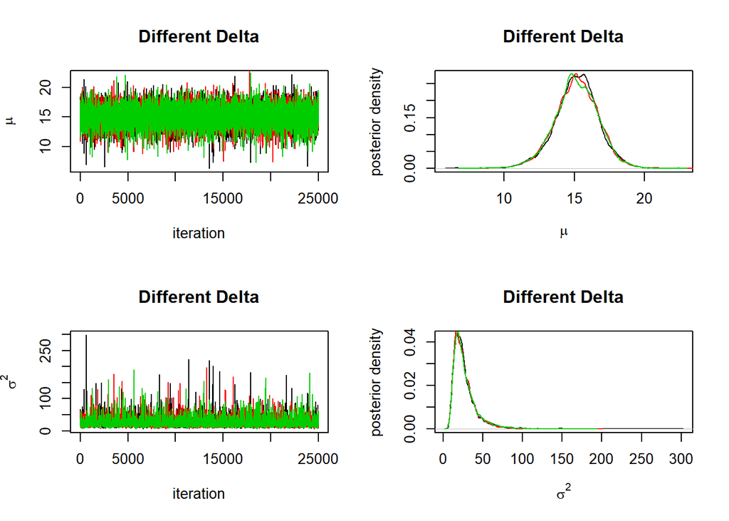

```r
# 2) 각 theta 원소의 분산을 고려한 값.
nChains=3
nsim=25000 ; nburn=0; p=2
mcmc.samples=array(0,dim=c(nsim,p,nChains)) # array to save samples

delta=delta_final ## 공통분산 사용


##start iteration
for (ich in 1:nChains){
  initsList=inits.random(x)
  mcmc.samples[,,ich]=Metropolis_normal_mu_sigsq_adj(nsim,nburn,delta,dataList,initsList)
}

mu.samples=mcmc.samples[,1,]
sigsq.samples=mcmc.samples[,2,]

par(mfrow = c(2,2))
plot(mu.samples[,1],type="l",xlab="iteration",ylab=quote(mu), main = "Different Delta")
lines(mu.samples[,2],col=2)
lines(mu.samples[,3],col=3)

plot(density(mu.samples[,1]),xlab=quote(mu),ylab="posterior density",main="Different Delta")
lines(density(mu.samples[,2]),col=2)
lines(density(mu.samples[,3]),col=3)

plot(sigsq.samples[,1],type="l",xlab="iteration",ylab=quote(sigma^2), main = "Different Delta")
lines(sigsq.samples[,2],col=2)
lines(sigsq.samples[,3],col=3)

plot(density(sigsq.samples[,1]),xlab=quote(sigma^2),ylab="posterior density",main="Different Delta")
lines(density(sigsq.samples[,2]),col=2)
lines(density(sigsq.samples[,3]),col=3)
```

```r
#### Posterior inference ####
mcmc.samples.combined = rbind(mcmc.samples[,,1], mcmc.samples[,,2], mcmc.samples[,,3])
para.hat = apply(mcmc.samples.combined, 2, mean)
HPD = apply(mcmc.samples.combined, 2, function(x) quantile(x, c(0.025, 0.975)))
HPD
```

```
##           [,1]     [,2]
## 2.5%  11.84144 10.47766
## 97.5% 18.12968 66.18128
```

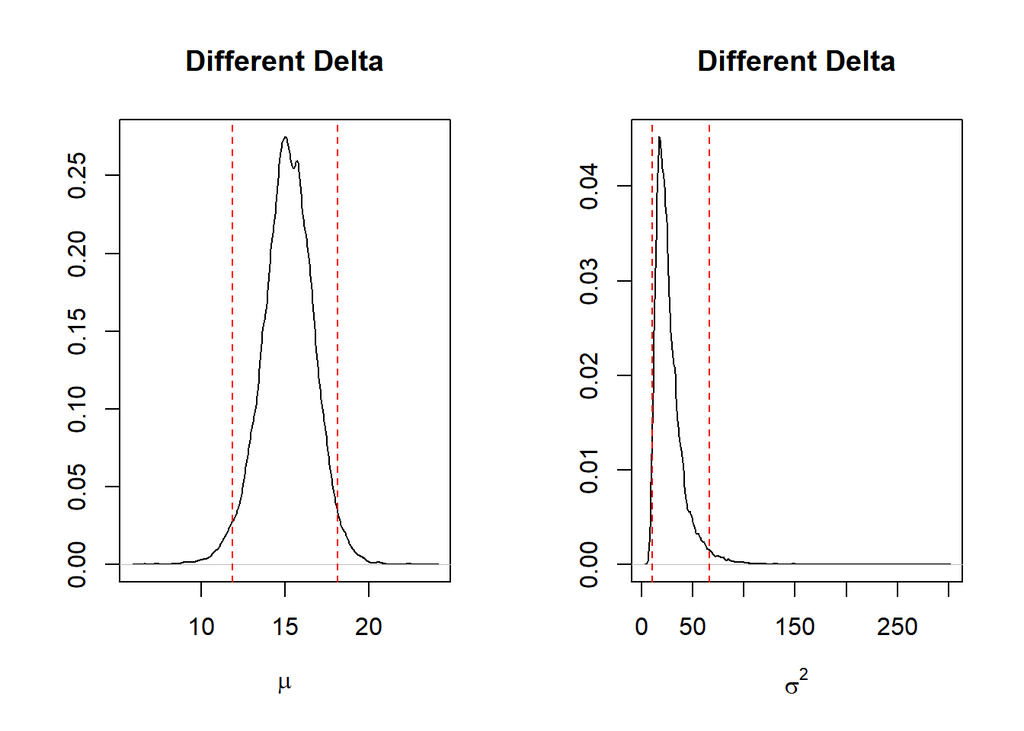

```r
#### mu와 sigma의 주변 사후밀도함수와 95% HPD 구간 ####
par(mfrow = c(1,2))
plot(density(mcmc.samples.combined[,1]), xlab = quote(mu), ylab = "", main = "Different Delta")
abline(v = HPD[,1], lty = 2, col = 2)
plot(density(mcmc.samples.combined[,2]), xlab = quote(sigma^2), ylab = "", main = "Different Delta")
abline(v = HPD[,2], lty = 2, col = 2)
```

공통 분산과 분산이 다른 경우 산 둘다 iteration 25,000와 burn-in 0으로 설정하였다. 경로그림비교해보면 모두 하나의 분포로 수렴하였다.

공통 분산과 분산이 다른 경우 모두 mu의 경로그림에서 공통 분산보다 분산다른 경우 chain들이 더 잘 겹친다는 점을 제외하고 두개의 분산 모두 결과가 비슷하다.

공통 분산보다 분산이 다른 경우가 좀 더 채택확률이 0.234에 가깝기 때문에 일반적으로 수렴의 속도가 빠르고 사후밀도함수의 95% HPD 구간 좁을 것이지만 이 경우에는 mcmc를 충분히 길게 수행했기 때문인같다.